# R y análisis de redes sociales - clase 1

**¿Qué necesito para el curso?**

Necesitamos la [útlima instalación de R](http://cran.r-project.org/) y [RStudio](https://www.rstudio.com/). Adicionalmente instalaremos el paquete igraph para R:

```r
install.packages("igraph")
```

**Breve introducción: ¿De que se trata el R?**

R es un entorno y un lenguaje de programación enfocado en el análisis de datos de los más utilizados en el campo del data mining que pueden aplicarse a gran variedad de disciplinas.

Particularmente nos sirve por la posibilidad de integrar diferentes fuentes de datos y generar análisis con metodologías que conocemos (ARS, simulaciones basadas en agentes, modelos estadísticos, etc) en una misma plataforma de reconocimiento compartido no solo por la comunidad acádemica, sino también por todos aquellos que estan trabajando en ciencia de datos.

Todo lo que se hace con otras herramientas se puede hacer con R (sql, spss, xml, excel, sas, stata, oracle, access, netlogo, ucinet, etc)

Además la curva de aprendizaje de R es “como aprender a tocar la guitarra”. Una vez que se hace el salto inicial incorporar comandos es bastante más simple que en otros lenguajes.

**Características y ventajas de la programación en R**

- El lenguaje de programación R es un proyecto colaborativo y abierto, los desarrolladores pueden descargar el código de forma gratuita y modificarlo para incluir mejoras.
- Es un lenguaje interpretado, funciona mediante comandos.
- R proporciona una amplia gama de herramientas estadísticas que incluyen análisis de datos y generación de gráficos. Este lenguaje tiene capacidad de generar gráficos de alta calidad. Estas características lo convierten en una potente herramienta de cálculo.
- Gracias a este lenguaje de programación los Data Scientists pueden manejar grandes volúmenes de datos.
- Puede integrarse con distintas bases de datos. Una de las ventajas más importantes de R es que funciona con diferentes tipos de hardware y software (Windows, Unix, Linux.)
- El lenguaje R ofrece la posibilidad de cargar bibliotecas y paquetes con diversas funcionalidades lo que permite a los usuarios extender su configuración básica.
- La comunidad en torno a R es muy activa por lo que es sencillo encontrar soluciones rápidamente a los problemas que los usuarios se puedan encontrar.

Más información en http://blog.datatons.com/2016/04/08/que-es-lenguaje-programacion-r/

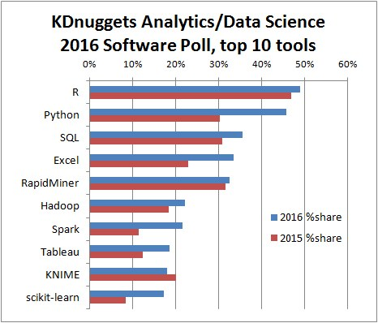

[figure not shown]

**Comandos Básicos en R**

R es “casesensitive” por lo tanto importan las mayúsculas y minúsculas en los nombres de las variables.

La mayoría de los errores en el código son por cuestiones menores, como el tipo de letras, las comillas y detalles de ese tipo.

En general el tipo de sintaxis que requiere R es largamente más simplificada que otros lenguajes de programación.

**Asignación de valores:** Asignación de un valor a una variable

```r
x <- 3 # asignación del valor 3 a la variable x

x # ¿Que aparece si corró la variable x?

y <- 4 # asignación del valor 4 a la variable y

y + 5 # R permite hacer operaciones de manera directa combinando variables y números

z <- x + 17*y # O generar nuevas variables a partir de otras antes armadas

z
```

Todo se genera en la memoria de la computadora, por eso ante grandes volumenes de información es necesario tener una buena cantidad de memoria RAM. Los variables pueden eliminarse directamente desde el código o desde la ventana de “enviroment” en RStudio

```r
rm(z) # Eliminar z: Elimina el objeto object.
z # Si ahora llamamos al vector nos tira un error.
```

**Vectores**

R no trabaja solamente con variables, sino que mayormente lo hace con vectores. La lógica para la creación de los mismos es similar, solo que vectores pueden ser más amplios.

```r
v1 <- c(1, 5, 11, 33) # Numeric vector, length 4
v2 <- c("hello","world") # Character vector, length 2 (a vector of strings)
v3 <- c(TRUE, TRUE, FALSE) # Logical vector, same as c(T, T, F)
```

Si un vector incluye diferentes tipos de datos, toma por default para todo el grupo las carácteristicas del último ingresado.

```r
v4 <- c(v1,v2,v3,"boo") # All elements turn into strings
```

Otras maneras de crear vectores:

```r
v <- 1:7 # same as c(1,2,3,4,5,6,7)
v <- rep(0, 77) # repeat zero 77 times: v is a vector of 77 zeroes
v <- rep(1:3, times=2) # Repeat 1,2,3 twice
v <- rep(1:10, each=2) # Repeat each element twice
v <- seq(10,20,2) # sequence: numbers between 10 and 20, in jumps of 2
v1 <- 1:5 # 1,2,3,4,5
v2 <- rep(1,5) # 1,1,1,1,1
```

Es posible realizar operaciones entre vectores siempre que sean del mismo tamaño

```r
v1 + v2 # Element-wise addition
v1 + 1 # Add 1 to each element
v1 * 2 # Multiply each element by 2
v1 + c(1,7) # This doesn't work: (1,7) is a vector of different length
```

También se pueden realizar operaciones al interior del propio vectore

```r
sum(v1) # The sum of all elements
mean(v1) # The average of all elements
sd(v1) # The standard deviation
cor(v1,v1*5) # Correlation between v1 and v1*5
```

Y también realizar operaciones lógicas que devuelvan un TRUE / FALSE de resultado

```r
v1 > 2 # Each element is compared to 2, returns logical vector
v1==v2 # Are corresponding elements equivalent, returns logical vector.
```

**Factores**

Los factores se utilizan para datos del tipo categorico

```r
eye.col.v <- c("brown", "green", "brown", "blue", "blue", "blue") #vector
eye.col.f <- factor(c("brown", "green", "brown", "blue", "blue", "blue")) #factor
eye.col.v
```

## [1] “brown” “green” “brown” “blue” “blue” “blue”

```r
eye.col.f
```

## [1] brown green brown blue blue blue

## Levels: blue brown green

R identifica los distintos niveles (categorias) de los factores

```r
levels(eye.col.f)
```

Se los puede leer como “númericos”

```r
as.numeric(eye.col.f) # As numeric values: 1 is blue, 2 is brown, 3 is green
```

**Primeras aproximaciones a las redes**

Para trabajar con redes utilizaremos el paquete igraph.

R funciona con distintos paquetes en función del análisis o la visualización de lo que se este buscando realizar. Hay múltiples paquetes para los mismos análisis, generalmente están altamente documentados.

Estos son los paquetes más populares, el ggplot2 es el de visualización Rcpp integra con C++

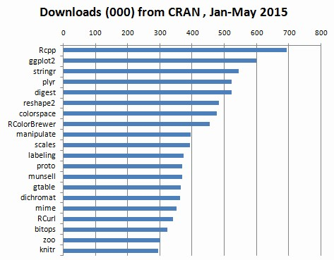

Siempre antes de empezar un proyecto hay que setear la carpeta donde lo va a trabajar

```r
setwd('/Users/BRAIN/Documents/Antropocaos/clase1')
```

Y es una buena práctica borrar la memoria para que no haya otros datasets interfiriendo

```r
#limpia la memoria
rm(list=ls()) #remove
gc() #garbage collector
```

Si ya tenemos instalado el paquete, hay que cargar la libreria correspondiente.

```r
library(igraph) # Load the igraph package
```

R utiliza la lógica de Gephi o Graph Commons en cuanto al armado de las redes, el dato es el vinculo y no la matriz cuadrada a la manera de UCInet u ORA.

Crear una web manualmente implica lo siguiente:

```r
g1 <- graph( edges=c(1,2, 2,3, 3, 1), n=3, directed=F )
```

El código genera un grafo no direccionado de tres ejes, donde cada número representa uno de los nodos. Las relaciones son 1->2, 2->3, 3->1.

Para graficar en R se usa el comando plot, pero depende del tipo de gràfico y el paquete que se este utilizado.

```r
plot(g1)
```

[output not shown]

Si quiere ver el contenido de la red puedo “llamarla”

```r
g1
```

Hagamos una red con más nodos pero no todos conectados

```r
g2 <- graph( edges=c(1,2, 2,3, 3, 1), n=10 )

plot(g2) #la llamo para graficarla
```

[output not shown]

ver informaciòn

```r
g2
```

Redes con nombres

```r
g3 <- graph( c("John", "Jim", "Jim", "Jill", "Jill", "John")) # named vertices
# When the edge list has vertex names, the number of nodes is not needed

plot(g3)
```

[output not shown]

ver informaciòn

```r
g3
```

Redes pequeñas se pueden armar con un código más simplificado y directo al gràfico.

```r
plot(graph_from_literal(a---b, b---c)) # the number of dashes doesn't matter
```

una variante direccionada

```r
plot(graph_from_literal(a--+b, b+--c))
```

variante barrilete

```r
plot(graph_from_literal(a:b:c---c:d:e))
```

variante compañerito nuevo

```r
gl <- graph_from_literal(a-b-c-d-e-f, a-g-h-b, h-e:f:i, j)
plot(gl)
```

**Nodos, vìnculos y atributos**

```r
E(g4) # The edges of the object
```

[output not shown]

```
+ 4/4 edges from 628827f (vertex names):
[1] John->Jim  Jim ->Jack Jim ->Jack John->John
```

## + 4/4 edges (vertex names):

## [1] John->Jim Jim ->Jack Jim ->Jack John->John

```r
V(g4)
```

```
+ 7/7 vertices, named, from 628827f:
[1] John     Jim      Jack     Jesse    Janis    Jennifer Justin
```

## + 7/7 vertices, named:

## [1] John Jim Jack Jesse Janis Jennifer Justin

Tambièn se puede ver la matriz directamente

```r
g4[]
```

```
7 x 7 sparse Matrix of class "dgCMatrix"
         John Jim Jack Jesse Janis Jennifer Justin
John        1   1    .     .     .        .      .
Jim         .   .    2     .     .        .      .
Jack        .   .    .     .     .        .      .
Jesse       .   .    .     .     .        .      .
Janis       .   .    .     .     .        .      .
Jennifer    .   .    .     .     .        .      .
Justin      .   .    .     .     .        .      .
```

```r
g4[1,]
```

¿que piensan que hace eso?

Se puede ver volviendo a correr la matriz o el gràfico

```r
g4[]
```

[output not shown]

Agregar atributos

```r
V(g4)$name # automatically generated when we created the network.
```

otros atributos

```r
V(g4)$gender <- c("male", "male", "male", "male", "female", "female", "male")
E(g4)$type <- "email" # Edge attribute, assign "email" to all edges
E(g4)$weight <- 10 # Edge weight, setting all existing edges to 10
```

Examinar atributos

```r
edge_attr(g4)
vertex_attr(g4)
graph_attr(g4)
```

Una muy buena de R, es que se puede acceder a la ayuda, que en general es muy completa, de cada comando

Graficar la red hasta acà

```r
plot(g4, edge.arrow.size=.5, vertex.label.color="black", vertex.label.dist=1.5,
vertex.color=c( "pink", "skyblue")[1+(V(g4)$gender=="male")] )
```

[output not shown]

Simplificar la red

```r
g4s <- simplify( g4, remove.multiple = T, remove.loops = F,
edge.attr.comb=c(weight="sum", type="ignore") ) #fijense que no pisa el nombre del archivo original
plot(g4s, vertex.label.dist=1.5)
```

[output not shown]

**Gráficos Específicos y modelos**

gràfico vacio (sin relaciones)

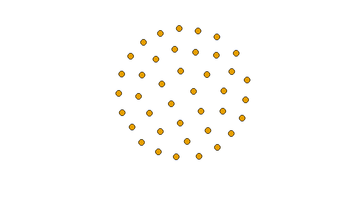

gráfico somos todos muy amigos de todos

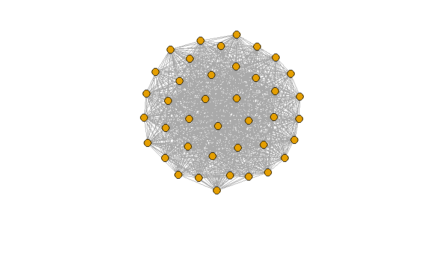

gráfico de paul stanley

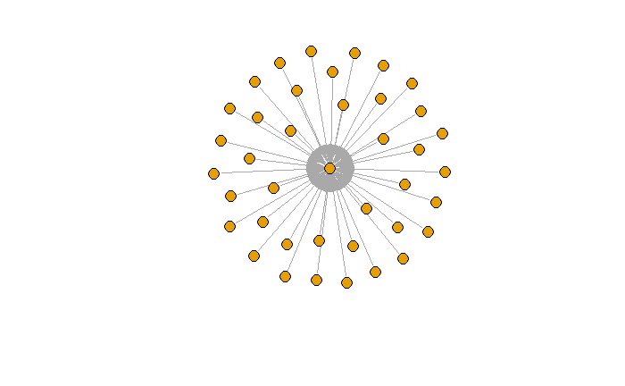

arbolito

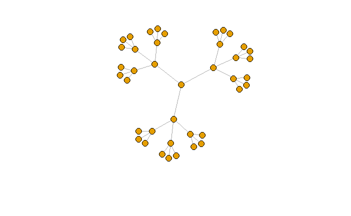

surtido

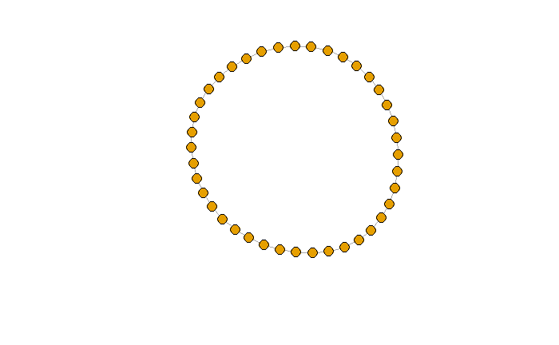

Erdos-Renyi random graph model (‘n’ es el número de nodods, ‘m’ el de relaciones)

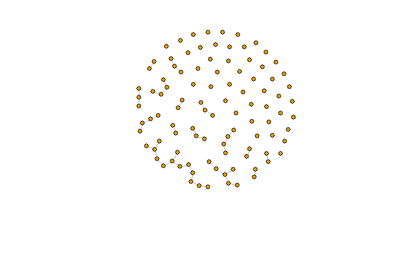

El mundo pequeño de Watts

Creates a lattice (with dim dimensions and size nodes across dimension) and rewires edges randomly with probability p. The neighborhood in which edges are connected is nei. You can allow loops and multiple edges.

```r
sw <- sample_smallworld(dim=2, size=10, nei=1, p=0.1)
plot(sw, vertex.size=6, vertex.label=NA, layout=layout_in_circle)
```

[output not shown]

Barabasi libre de escala

(n is number of nodes, power is the power of attachment (1 is linear); m is the number of edges added on each time step)

```r
ba <- sample_pa(n=100, power=1, m=1, directed=F)
plot(ba, vertex.size=6, vertex.label=NA)
```

[output not shown]

El paquete de igraph viene preseteados algunos gràficos tradicionales de ARS Como el del club de Karate

```r
zach <- graph("Zachary") # the Zachary carate club
plot(zach, vertex.size=10, vertex.label=NA)
```

[output not shown]

**leer data externa**

Buena parte de la potencia de R esta en la capacidad de trabajar con grandes volumenes de datos externos.

Básicamente el primer paso consiste en “levantar el dataset”

Para eso hay varios comandos, el más común es el read.csv (pasar una base a CSV es bastante accesible). De todas maneras funciona de manera similar en otros formatos, por lo que existe un read.txt o read.xlm

Para levantar datos de una red hay que definirle que son nodos y que relaciones

```r
nodes <- read.csv("Dataset1-Media-Example-NODES.csv", header=T, as.is=T)
links <- read.csv("Dataset1-Media-Example-EDGES.csv", header=T, as.is=T)
```

Lo siguientes comandos son los habituales para hacer un anàlisis general de lso datos del set

```r
head(nodes)
head(links)
nrow(nodes); length(unique(nodes$id))
nrow(links); nrow(unique(links[,c("from", "to")]))
```